# Examen 2.2 - Instrumentos Financieros

# Ejercicio 1

Una acción cuyo precio es de $30 tiene una rentabilidad esperada del 9% y una volatilidad del 20%.

## Inciso (a)

Simule la trayectoria del precio de la acción a lo largo de 5 años utilizando pasos temporales mensuales y muetsras aleatorias de una distribución normal.

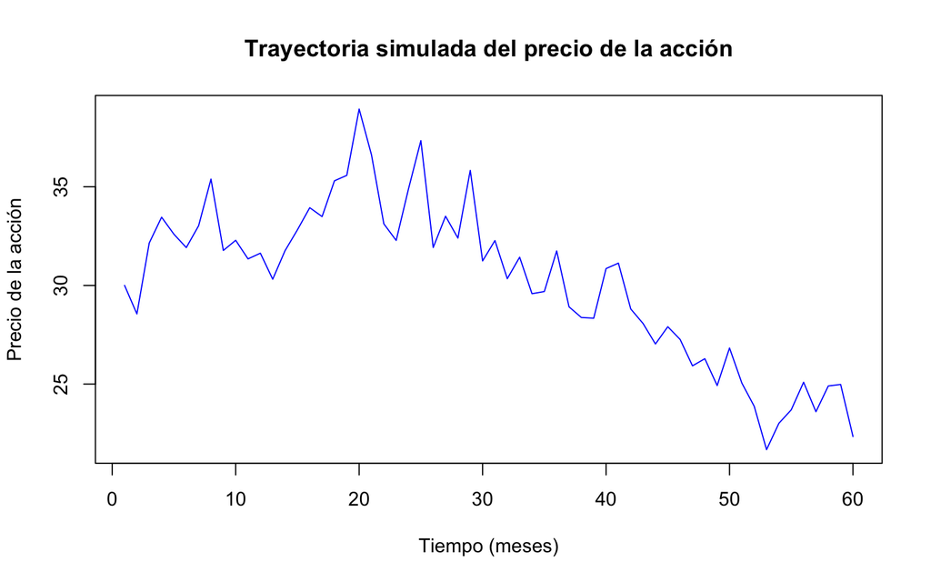

```r
# Datos
mu <- 0.09
sigma <- 0.2
dt <- 1 / 12
t <- 5

# Vector para guardar las simulaciones
S <- numeric(t * (1 / dt))
S[1] <- 30

# Simulación de la trayectoria
for (i in 2:(t * (1 / dt))) {
  S[i] <- S[i - 1] * (1 + mu * dt + sigma * rnorm(1) * sqrt(dt))
}

# Gráfico
plot(1:(t * (1 / dt)), S, type = "l", col = rgb(0, 0, 1), lwd = 1,
     xlab = "Tiempo (meses)", ylab = "Precio de la acción",
     main = "Trayectoria simulada del precio de la acción",
     ylim = range(S))
```

De manera explícita, los valores que toma el precio de la acción a lo largo de 5 años en la simulación corresponden a los siguientes:

```r
S
```

```
##  [1] 30.00000 28.55381 32.15134 33.45771 32.59383 31.91758 33.02661 35.38821
##  [9] 31.77253 32.28647 31.34487 31.63325 30.31449 31.76302 32.81586 33.93874
## [17] 33.48910 35.30150 35.57869 38.93834 36.61796 33.12225 32.28006 34.89719
## [25] 37.33808 31.92180 33.50742 32.39845 35.82775 31.24113 32.27332 30.34133
## [33] 31.43166 29.58027 29.69035 31.74759 28.91517 28.37421 28.33870 30.85371
## [41] 31.12926 28.80653 28.06688 27.03134 27.90813 27.26081 25.92426 26.28533
## [49] 24.92443 26.82799 25.04917 23.87357 21.67621 23.01293 23.69522 25.09244
## [57] 23.59725 24.90356 24.98083 22.34292
```

## Inciso (b)

Represente gráficamente 20 trayectorias simuladas del precio de la acción en el mismo gráfico.

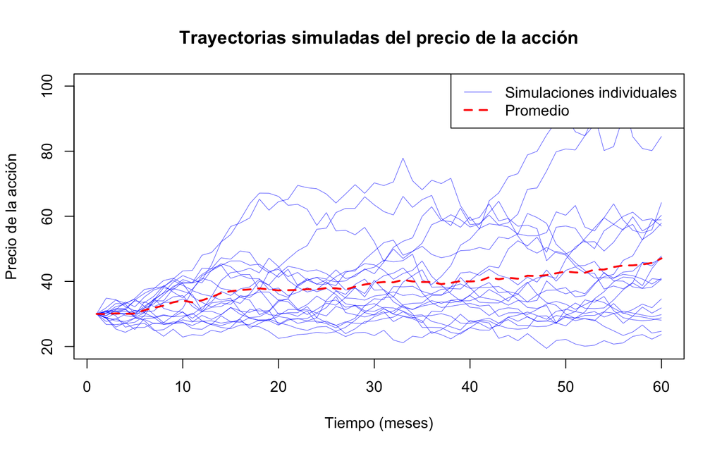

```r
n_sim <- 20

# Matriz para guardar las simulaciones
S <- matrix(0, nrow = t * (1 / dt), ncol = n_sim)
S[1, ] <- 30

# Simulaciones de la trayectoria del precio de la acción
for (j in 1:n_sim) {
  for (i in 2:(t * (1 / dt))) {
    S[i, j] <- S[i - 1, j] * (1 + mu * dt + sigma * rnorm(1) * sqrt(dt))
  }
}

# Gráfico
plot(1:(t * (1 / dt)), S[, 1], type = "l", col = rgb(0, 0, 1, 0.75), lwd = 0.5,
     xlab = "Tiempo (meses)", ylab = "Precio de la acción",
     main = "Trayectorias simuladas del precio de la acción",
     ylim = range(S))

for (j in 2:n_sim) {
  lines(1:(t * (1 / dt)), S[, j], col = rgb(0, 0, 1, 0.75), lwd = 0.5)
}

lines(1:(t * (1 / dt)), rowMeans(S), col = "red", lwd = 2, lty = 2)
legend("topright", legend = c("Simulaciones individuales", "Promedio"),
       col = c(rgb(0, 0, 1, 0.5), "red"), lty = c(1, 2), lwd = c(1, 2))
```

## Inciso (c)

Repita el paso anterior con volatilidad del 30% y del 50%, detalle lo que observa y si eso está en línea con la definición de volatilidad.

### Caso con volatilidad del 30%:

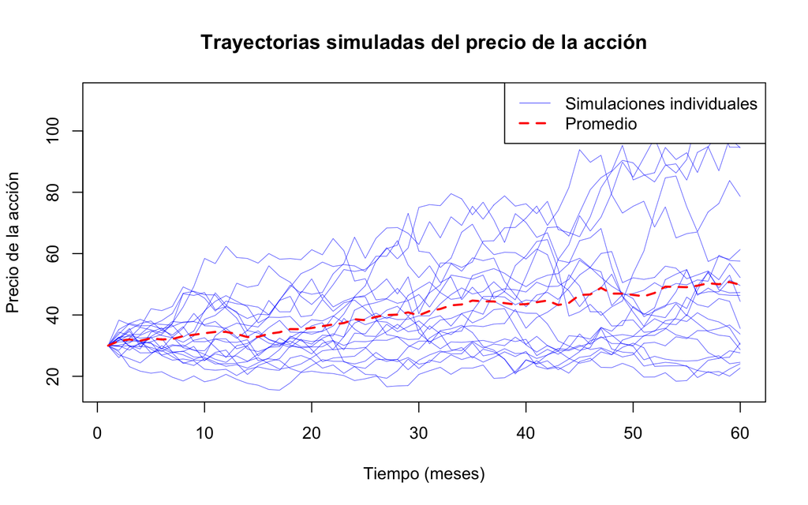

```r
sigma <- 0.3

# Matriz para guardar las simulaciones
S <- matrix(0, nrow = t * (1 / dt), ncol = n_sim)
S[1, ] <- 30

# Simulaciones de la trayectoria del precio de la acción
for (j in 1:n_sim) {
  for (i in 2:(t * (1 / dt))) {
    S[i, j] <- S[i - 1, j] * (1 + mu * dt + sigma * rnorm(1) * sqrt(dt))
  }
}

# Gráfico
plot(1:(t * (1 / dt)), S[, 1], type = "l", col = rgb(0, 0, 1, 0.75), lwd = 0.5,
     xlab = "Tiempo (meses)", ylab = "Precio de la acción",
     main = "Trayectorias simuladas del precio de la acción",
     ylim = range(S))

for (j in 2:n_sim) {
  lines(1:(t * (1 / dt)), S[, j], col = rgb(0, 0, 1, 0.75), lwd = 0.5)
}

lines(1:(t * (1 / dt)), rowMeans(S), col = "red", lwd = 2, lty = 2)
legend("topright", legend = c("Simulaciones individuales", "Promedio"),
       col = c(rgb(0, 0, 1, 0.5), "red"), lty = c(1, 2), lwd = c(1, 2))
```

### Caso con volatilidad del 50%:

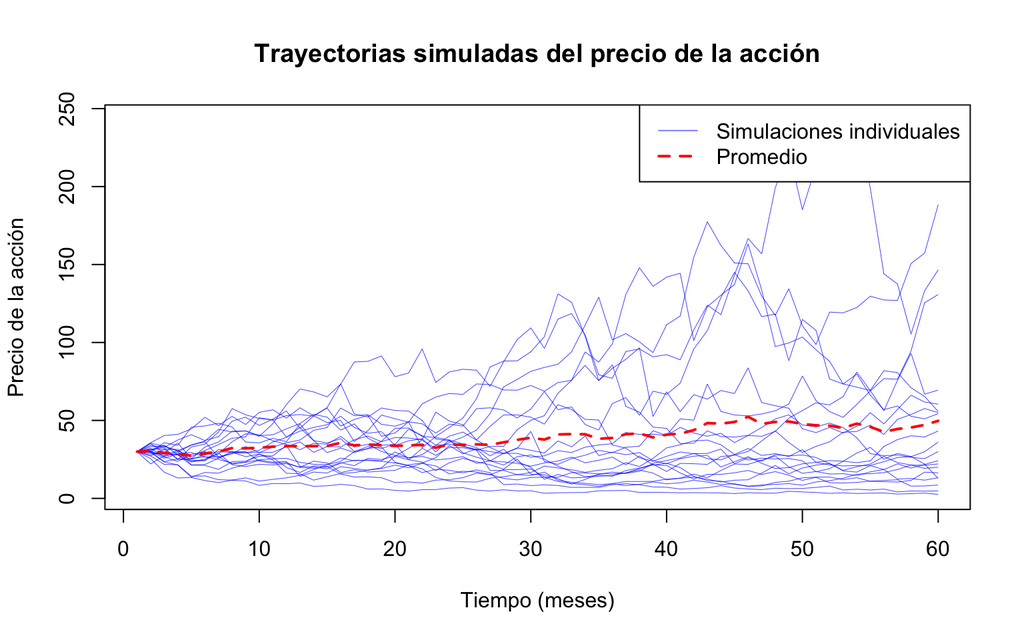

```r
sigma <- 0.5

# Matriz para guardar las simulaciones
S <- matrix(0, nrow = t * (1 / dt), ncol = n_sim)
S[1, ] <- 30

# Simulaciones de la trayectoria del precio de la acción
for (j in 1:n_sim) {
  for (i in 2:(t * (1 / dt))) {
    S[i, j] <- S[i - 1, j] * (1 + mu * dt + sigma * rnorm(1) * sqrt(dt))
  }
}

# Gráfico
plot(1:(t * (1 / dt)), S[, 1], type = "l", col = rgb(0, 0, 1, 0.75), lwd = 0.5,
     xlab = "Tiempo (meses)", ylab = "Precio de la acción",
     main = "Trayectorias simuladas del precio de la acción",
     ylim = range(S))

for (j in 2:n_sim) {
  lines(1:(t * (1 / dt)), S[, j], col = rgb(0, 0, 1, 0.75), lwd = 0.5)
}

lines(1:(t * (1 / dt)), rowMeans(S), col = "red", lwd = 2, lty = 2)
legend("topright", legend = c("Simulaciones individuales", "Promedio"),
       col = c(rgb(0, 0, 1, 0.5), "red"), lty = c(1, 2), lwd = c(1, 2))
```

Podemos ver que a medida que la volatilidad aumenta, las trayectorias se vuelven más dispersas y muestran fluctuaciones más extremas. Esto lo podemos corroborar gráficamente en lo siguiente:

1. Hay una mayor amplitud de las trayectorias individuales, ya que con una volatilidad más alta, las fluctuaciones en los precios simulados son más grandes, lo que genera movimientos más pronunciados y menos predecibles.
2. Hay un aumento significativo en el rango del eje y, ya que a mayores variaciones en los precios, el rango del eje vertical necesite expandirse para abarcar los valores extremos alcanzados por las trayectorias simuladas.

Al aumentar la volatilidad, se tiene mayor incertidumbre, ya que esta representa el grado de variación o dispersión del precio alrededor de su media esperada. Volatilidades más altas implican mayor incertidumbre sobre los posibles precios futuros.

Esto concuerda con la teoría financiera, donde la volatilidad mide el riesgo asociado a un activo. Cuando $\sigma$ aumenta, la posibilidad de obtener precios significativamente diferentes también crece. Esto es observable en las simulaciones, donde las trayectorias individuales divergen más unas de otras.

# Extra

Lo agregamos porque se ve muy bonito y vale la pena verlo.

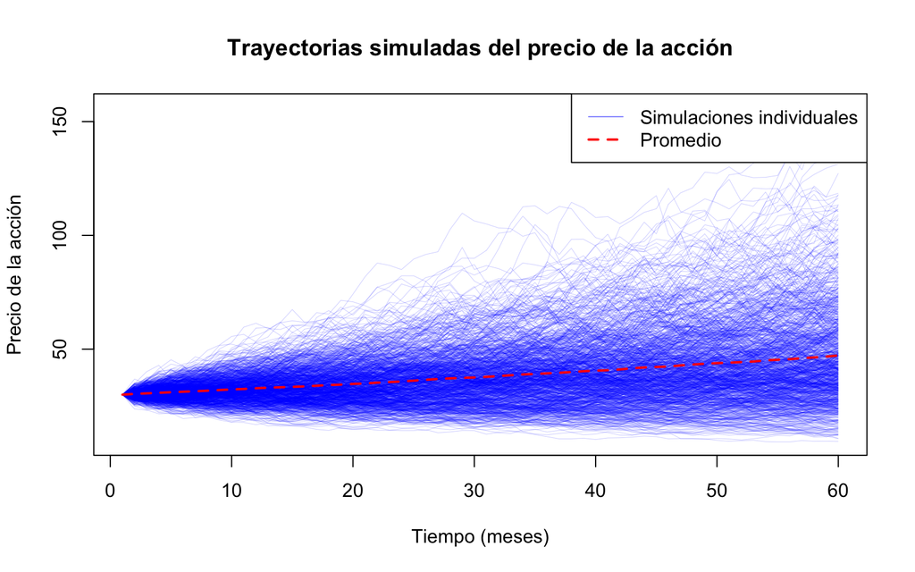

```r
mu <- 0.09
sigma <- 0.2
dt <- 1 / 12
t <- 5
n_sim <- 1000

S <- matrix(0, nrow = t * (1 / dt), ncol = n_sim)
S[1, ] <- 30

for(j in 1:n_sim) {
  for (i in 2:(t * (1 / dt))) {
    S[i, j] <- S[i - 1, j] * (1 + mu * dt + sigma * rnorm(1) * sqrt(dt))
  }
}

plot(1:(t * (1 / dt)), S[, 1], type = "l", col = rgb(0, 0, 1, 0.2), lwd = 0.5,
     xlab = "Tiempo (meses)", ylab = "Precio de la acción",
     main = "Trayectorias simuladas del precio de la acción",
     ylim = range(S))

for (j in 2:n_sim) {
  lines(1:(t * (1 / dt)), S[, j], col = rgb(0, 0, 1, 0.2), lwd = 0.5)
}

lines(1:(t * (1 / dt)), rowMeans(S), col = "red", lwd = 2, lty = 2)
legend("topright", legend = c("Simulaciones individuales", "Promedio"),
       col = c(rgb(0, 0, 1, 0.5), "red"), lty = c(1, 2), lwd = c(1, 2))
```